### The PwC Switzerland Churn Dataset

#### Explanatory Data analysis to understand the reasons for churning among members and the kinds of customers we should examine as “soon to churn”. Using the Churn dataset provided in the Pwc Virtual Internship program on Forage.

Lets take a peak look at the dataset we would be using, we load the important libraries and bring our data.

```r
pacman::p_load(pacman, dplyr, GGally, ggplot2, ggthemes,
               ggvis, httr, lubridate, plotly, rio, rmarkdown, shiny,
               stringr, tidyr, reticulate, tidyverse, psych)
```

```r
library(readxl)
ChurnData <- read_excel("C:/Users/user/Desktop/BI Analytics Projects/ChurnDataset.xlsx")
```

```r
CR <- ChurnData
head(CR)
```

```
## # A tibble: 6 × 23
##   customerID gender SeniorCitizen Partner Dependents tenure PhoneService
##   <chr>      <chr>          <dbl> <chr>   <chr>       <dbl> <chr>
## 1 7590-VHVEG Female             0 Yes     No              1 No
## 2 5575-GNVDE Male               0 No      No             34 Yes
## 3 3668-QPYBK Male               0 No      No              2 Yes
## 4 7795-CFOCW Male               0 No      No             45 No
## 5 9237-HQITU Female             0 No      No              2 Yes
## 6 9305-CDSKC Female             0 No      No              8 Yes
## # ℹ 16 more variables: MultipleLines <chr>, InternetService <chr>,
## #   OnlineSecurity <chr>, OnlineBackup <chr>, DeviceProtection <chr>,
## #   TechSupport <chr>, StreamingTV <chr>, StreamingMovies <chr>,
## #   Contract <chr>, PaperlessBilling <chr>, PaymentMethod <chr>,
## #   MonthlyCharges <dbl>, TotalCharges <dbl>, numAdminTickets <dbl>,
## #   numTechTickets <dbl>, Churn <chr>
```

Lets look at the column names

```r
colnames(CR)
```

```
##  [1] "customerID"       "gender"           "SeniorCitizen"    "Partner"
##  [5] "Dependents"       "tenure"           "PhoneService"     "MultipleLines"
##  [9] "InternetService"  "OnlineSecurity"   "OnlineBackup"     "DeviceProtection"
## [13] "TechSupport"      "StreamingTV"      "StreamingMovies"  "Contract"
## [17] "PaperlessBilling" "PaymentMethod"    "MonthlyCharges"   "TotalCharges"
## [21] "numAdminTickets"  "numTechTickets"   "Churn"
```

The Type of data each columns contains.

```r
str(CR)
```

```
## tibble [7,043 × 23] (S3: tbl_df/tbl/data.frame)
##  $ customerID      : chr [1:7043] "7590-VHVEG" "5575-GNVDE" "3668-QPYBK" "7795-CFOCW" ...
##  $ gender          : chr [1:7043] "Female" "Male" "Male" "Male" ...
##  $ SeniorCitizen   : num [1:7043] 0 0 0 0 0 0 0 0 0 0 ...
##  $ Partner         : chr [1:7043] "Yes" "No" "No" "No" ...
##  $ Dependents      : chr [1:7043] "No" "No" "No" "No" ...
##  $ tenure          : num [1:7043] 1 34 2 45 2 8 22 10 28 62 ...
##  $ PhoneService    : chr [1:7043] "No" "Yes" "Yes" "No" ...
##  $ MultipleLines   : chr [1:7043] "No phone service" "No" "No" "No phone service" ...
##  $ InternetService : chr [1:7043] "DSL" "DSL" "DSL" "DSL" ...
##  $ OnlineSecurity  : chr [1:7043] "No" "Yes" "Yes" "Yes" ...
##  $ OnlineBackup    : chr [1:7043] "Yes" "No" "Yes" "No" ...
##  $ DeviceProtection: chr [1:7043] "No" "Yes" "No" "Yes" ...
##  $ TechSupport     : chr [1:7043] "No" "No" "No" "Yes" ...
##  $ StreamingTV     : chr [1:7043] "No" "No" "No" "No" ...
##  $ StreamingMovies : chr [1:7043] "No" "No" "No" "No" ...
##  $ Contract        : chr [1:7043] "Month-to-month" "One year" "Month-to-month" "One year" ...
##  $ PaperlessBilling: chr [1:7043] "Yes" "No" "Yes" "No" ...
##  $ PaymentMethod   : chr [1:7043] "Electronic check" "Mailed check" "Mailed check" "Bank transfer (automatic)" ...
##  $ MonthlyCharges  : num [1:7043] 29.9 57 53.9 42.3 70.7 ...
##  $ TotalCharges    : num [1:7043] 29.9 1889.5 108.2 1840.8 151.7 ...
##  $ numAdminTickets : num [1:7043] 0 0 0 0 0 0 0 0 0 0 ...
##  $ numTechTickets  : num [1:7043] 0 0 0 3 0 0 0 0 2 0 ...
##  $ Churn           : chr [1:7043] "No" "No" "Yes" "No" ...
```

**Unlike the Python analysis, the TotalCharges were Recorded as a Number** Checking the Descriptive Statistics of the Numeric Variables in the Dataset

```r
describe(CR)
```

```
##                   vars    n    mean      sd  median trimmed     mad   min
## customerID*          1 7043 3522.00 2033.28 3522.00 3522.00 2610.86  1.00
## gender*              2 7043    1.50    0.50    2.00    1.51    0.00  1.00
## SeniorCitizen        3 7043    0.16    0.37    0.00    0.08    0.00  0.00
## Partner*             4 7043    1.48    0.50    1.00    1.48    0.00  1.00
## Dependents*          5 7043    1.30    0.46    1.00    1.25    0.00  1.00
## tenure               6 7043   32.37   24.56   29.00   31.43   32.62  0.00
## PhoneService*        7 7043    1.90    0.30    2.00    2.00    0.00  1.00
## MultipleLines*       8 7043    1.94    0.95    2.00    1.93    1.48  1.00
## InternetService*     9 7043    1.87    0.74    2.00    1.84    1.48  1.00
## OnlineSecurity*     10 7043    1.79    0.86    2.00    1.74    1.48  1.00
## OnlineBackup*       11 7043    1.91    0.88    2.00    1.88    1.48  1.00
## DeviceProtection*   12 7043    1.90    0.88    2.00    1.88    1.48  1.00
## TechSupport*        13 7043    1.80    0.86    2.00    1.75    1.48  1.00
## StreamingTV*        14 7043    1.99    0.89    2.00    1.98    1.48  1.00
## StreamingMovies*    15 7043    1.99    0.89    2.00    1.99    1.48  1.00
## Contract*           16 7043    1.69    0.83    1.00    1.61    0.00  1.00
## PaperlessBilling*   17 7043    1.59    0.49    2.00    1.62    0.00  1.00
## PaymentMethod*      18 7043    2.57    1.07    3.00    2.59    1.48  1.00
## MonthlyCharges      19 7043   64.76   30.09   70.35   64.97   35.66 18.25
## TotalCharges        20 7032 2283.30 2266.77 1397.47 1970.14 1812.92 18.80
## numAdminTickets     21 7043    0.52    1.28    0.00    0.14    0.00  0.00
## numTechTickets      22 7043    0.42    1.25    0.00    0.05    0.00  0.00
## Churn*              23 7043    1.27    0.44    1.00    1.21    0.00  1.00
##                       max  range  skew kurtosis    se
## customerID*       7043.00 7042.0  0.00    -1.20 24.23
## gender*              2.00    1.0 -0.02    -2.00  0.01
## SeniorCitizen        1.00    1.0  1.83     1.36  0.00
## Partner*             2.00    1.0  0.07    -2.00  0.01
## Dependents*          2.00    1.0  0.87    -1.23  0.01
## tenure              72.00   72.0  0.24    -1.39  0.29
## PhoneService*        2.00    1.0 -2.73     5.43  0.00
## MultipleLines*       3.00    2.0  0.12    -1.88  0.01
## InternetService*     3.00    2.0  0.21    -1.15  0.01
## OnlineSecurity*      3.00    2.0  0.42    -1.52  0.01
## OnlineBackup*        3.00    2.0  0.18    -1.68  0.01
## DeviceProtection*    3.00    2.0  0.19    -1.68  0.01
## TechSupport*         3.00    2.0  0.40    -1.54  0.01
## StreamingTV*         3.00    2.0  0.03    -1.72  0.01
## StreamingMovies*     3.00    2.0  0.01    -1.72  0.01
## Contract*            3.00    2.0  0.63    -1.27  0.01
## PaperlessBilling*    2.00    1.0 -0.38    -1.86  0.01
## PaymentMethod*       4.00    3.0 -0.17    -1.21  0.01
## MonthlyCharges     118.75  100.5 -0.22    -1.26  0.36
## TotalCharges      8684.80 8666.0  0.96    -0.23 27.03
## numAdminTickets      5.00    5.0  2.45     4.74  0.02
## numTechTickets       9.00    9.0  3.38    11.36  0.01
## Churn*               2.00    1.0  1.06    -0.87  0.01
```

Also 50% of the customers have spent less than 29 Months Since using Our services.

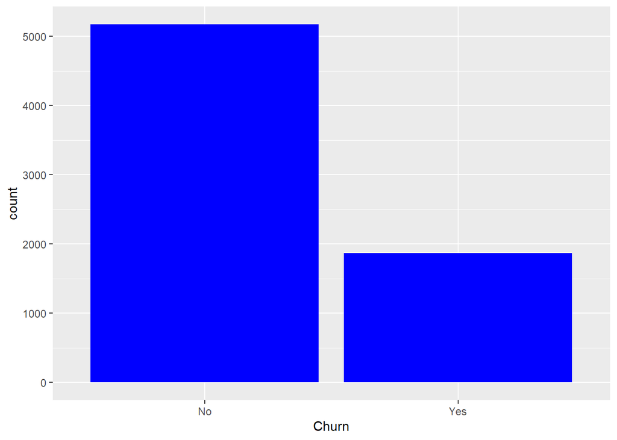

```r
ggplot(CR, aes(x = Churn)) + geom_bar(fill = 'Blue')
```

```r
CR |> count(Churn)
```

```
## # A tibble: 2 × 2
##   Churn     n
##   <chr> <int>
## 1 No     5174
## 2 Yes    1869
```

Lets find out How they Differ in percentage

```r
CR |> group_by(Churn) |> summarise(Percent = 100 * n()/ nrow(CR))
```

```
## # A tibble: 2 × 2
##   Churn Percent
##   <chr>   <dbl>
## 1 No       73.5
## 2 Yes      26.5
```

There are more customers in the Services that havent churned yet So we look to take them out of the equation and focus on the 1869 of them that churned and the reason for that **The Null values of the dataframe**

```r
colSums(is.na(CR))
```

```
##       customerID           gender    SeniorCitizen          Partner
##                0                0                0                0
##       Dependents           tenure     PhoneService    MultipleLines
##                0                0                0                0
##  InternetService   OnlineSecurity     OnlineBackup DeviceProtection
##                0                0                0                0
##      TechSupport      StreamingTV  StreamingMovies         Contract
##                0                0                0                0
## PaperlessBilling    PaymentMethod   MonthlyCharges     TotalCharges
##                0                0                0               11
##  numAdminTickets   numTechTickets            Churn
##                0                0                0
```

#### Missing Data - Initial Intuition

General Thumb Rules:

- For features with less missing values- can use regression to predict the missing values or fill with the mean of the values present, depending on the feature.
- For features with very high number of missing values- it is better to drop those columns as they give very less insight on analysis.
- As there’s no thumb rule on what criteria do we delete the columns with high number of missing values, but generally you can delete the columns, if you have more than 30-40% of missing values. But again there’s a catch here, for example, Is_Car & Car_Type, People having no cars, will obviously have Car_Type as NaN (null), but that doesn’t make this column useless, so decisions has to be taken wisely.

**We Create a new Dataframe for Manipulation, in our end the CR was created from the ChurnDataset, So we work With that.

**Missing Value Treatement**

THere are missing data values in the Totalcharges Column. Since the % of these records compared to total dataset is very low ie 0.15%, it is safe to ignore them from further processing.

```r
CR <- na.omit(CR)
```

```r
# Group the tenure in bins of 12 months
CR <- CR |> mutate(TenureGroup = cut(tenure, breaks = 6))
```

```r
str(CR)
```

```
## tibble [7,032 × 24] (S3: tbl_df/tbl/data.frame)
##  $ customerID      : chr [1:7032] "7590-VHVEG" "5575-GNVDE" "3668-QPYBK" "7795-CFOCW" ...
##  $ gender          : chr [1:7032] "Female" "Male" "Male" "Male" ...
##  $ SeniorCitizen   : num [1:7032] 0 0 0 0 0 0 0 0 0 0 ...
##  $ Partner         : chr [1:7032] "Yes" "No" "No" "No" ...
##  $ Dependents      : chr [1:7032] "No" "No" "No" "No" ...
##  $ tenure          : num [1:7032] 1 34 2 45 2 8 22 10 28 62 ...
##  $ PhoneService    : chr [1:7032] "No" "Yes" "Yes" "No" ...
##  $ MultipleLines   : chr [1:7032] "No phone service" "No" "No" "No phone service" ...
##  $ InternetService : chr [1:7032] "DSL" "DSL" "DSL" "DSL" ...
##  $ OnlineSecurity  : chr [1:7032] "No" "Yes" "Yes" "Yes" ...
##  $ OnlineBackup    : chr [1:7032] "Yes" "No" "Yes" "No" ...
##  $ DeviceProtection: chr [1:7032] "No" "Yes" "No" "Yes" ...
##  $ TechSupport     : chr [1:7032] "No" "No" "No" "Yes" ...
##  $ StreamingTV     : chr [1:7032] "No" "No" "No" "No" ...
##  $ StreamingMovies : chr [1:7032] "No" "No" "No" "No" ...
##  $ Contract        : chr [1:7032] "Month-to-month" "One year" "Month-to-month" "One year" ...
##  $ PaperlessBilling: chr [1:7032] "Yes" "No" "Yes" "No" ...
##  $ PaymentMethod   : chr [1:7032] "Electronic check" "Mailed check" "Mailed check" "Bank transfer (automatic)" ...
##  $ MonthlyCharges  : num [1:7032] 29.9 57 53.9 42.3 70.7 ...
##  $ TotalCharges    : num [1:7032] 29.9 1889.5 108.2 1840.8 151.7 ...
##  $ numAdminTickets : num [1:7032] 0 0 0 0 0 0 0 0 0 0 ...
##  $ numTechTickets  : num [1:7032] 0 0 0 3 0 0 0 0 2 0 ...
##  $ Churn           : chr [1:7032] "No" "No" "Yes" "No" ...
##  $ TenureGroup     : Factor w/ 6 levels "(0.929,12.8]",..: 1 3 1 4 1 1 2 1 3 6 ...
##  - attr(*, "na.action")= 'omit' Named int [1:11] 489 754 937 1083 1341 3332 3827 4381 5219 6671 ...
##   ..- attr(*, "names")= chr [1:11] "489" "754" "937" "1083" ...
```

**Lets drop the data columns that we are not using for analysis**

```r
CR <- subset(CR,select = -c(customerID,tenure))
```

### Data Exploration

**1. Plot distibution of individual predictors by churn**

Here we want to look at the Variables in the dataset counts and totals based on the Targeted Variable and have a clear information. it is known as **UNIVARIATE ANALYSIS**

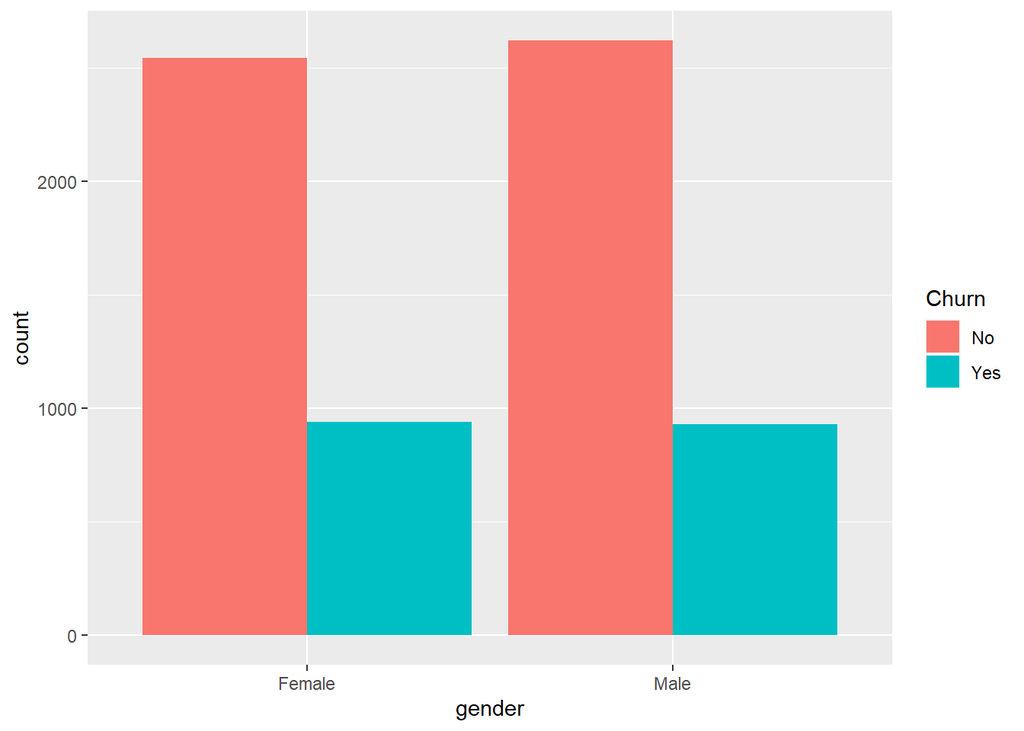

```r
ggplot(CR, aes(x = gender, fill = Churn)) + geom_bar(position = "dodge")
```

Lets look at the columns

```r
colnames(CR)
```

```
##  [1] "gender"           "SeniorCitizen"    "Partner"          "Dependents"
##  [5] "PhoneService"     "MultipleLines"    "InternetService"  "OnlineSecurity"
##  [9] "OnlineBackup"     "DeviceProtection" "TechSupport"      "StreamingTV"
## [13] "StreamingMovies"  "Contract"         "PaperlessBilling" "PaymentMethod"
## [17] "MonthlyCharges"   "TotalCharges"     "numAdminTickets"  "numTechTickets"
## [21] "Churn"            "TenureGroup"
```

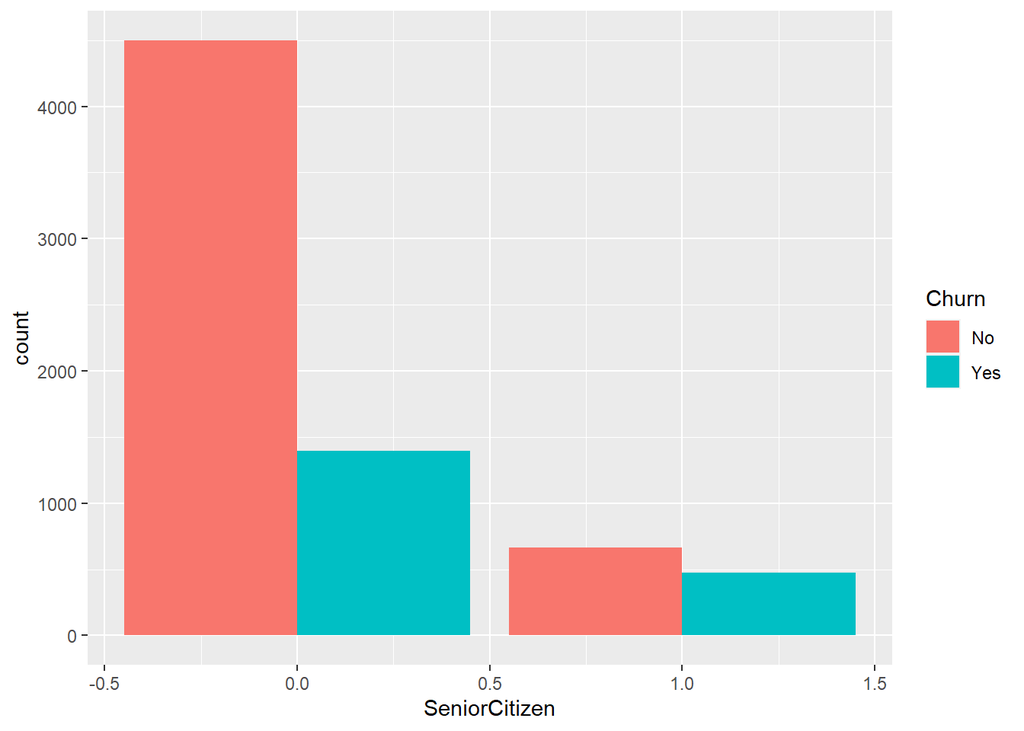

```r
ggplot(CR, aes(x = SeniorCitizen, fill = Churn)) + geom_bar(position = 'dodge')
```

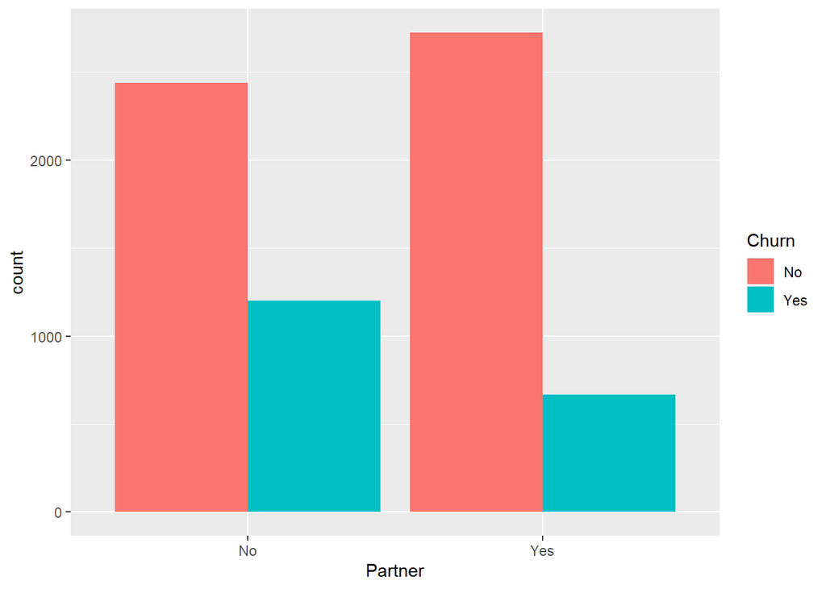

```r
ggplot(CR, aes(x = Partner, fill = Churn)) + geom_bar(position = 'dodge')
```

Lets run them in a group grid, Naming all the Plots

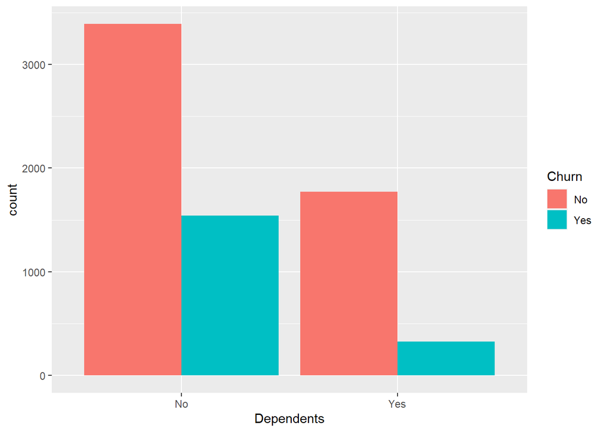

```r
ggplot(CR, aes(x = Dependents, fill = Churn)) + geom_bar(position = "dodge")
```

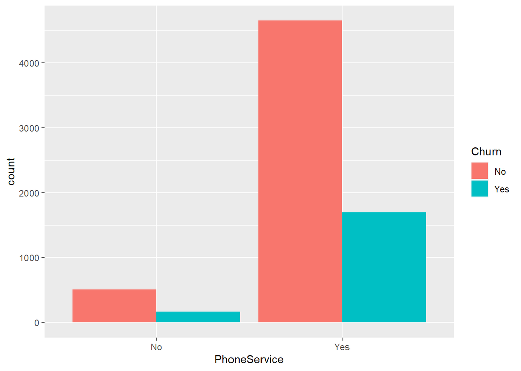

```r
ggplot(CR, aes(x = PhoneService, fill = Churn)) + geom_bar(position = "dodge")
```

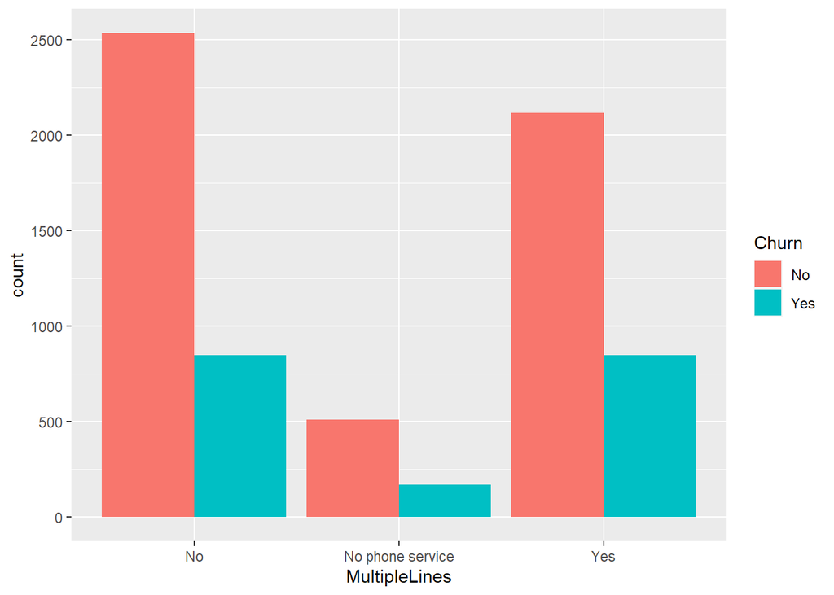

```r
ggplot(CR, aes(x = MultipleLines, fill = Churn)) + geom_bar(position = "dodge")
```

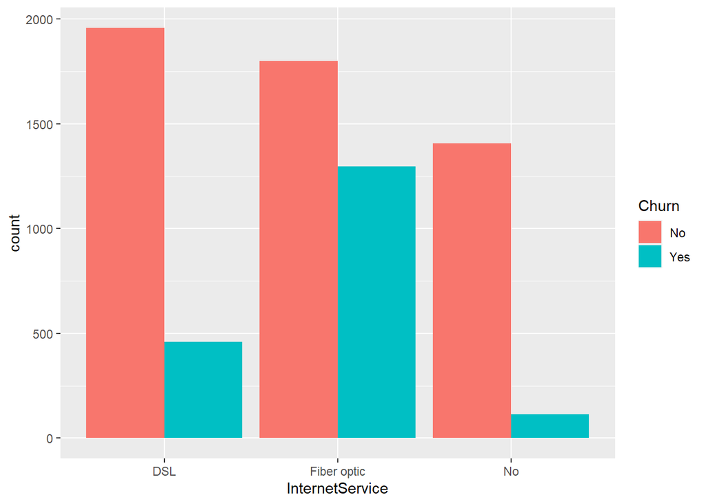

```r
ggplot(CR, aes(x = InternetService, fill = Churn)) + geom_bar(position = "dodge")
```

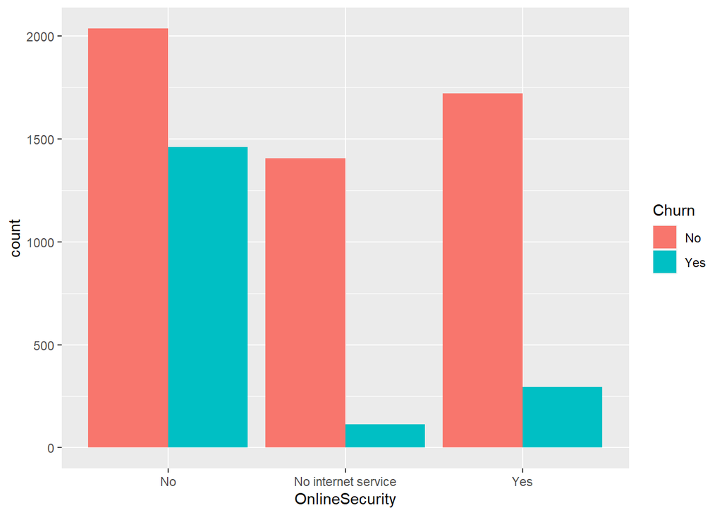

```r
ggplot(CR, aes(x = OnlineSecurity, fill = Churn)) + geom_bar(position = "dodge")
```

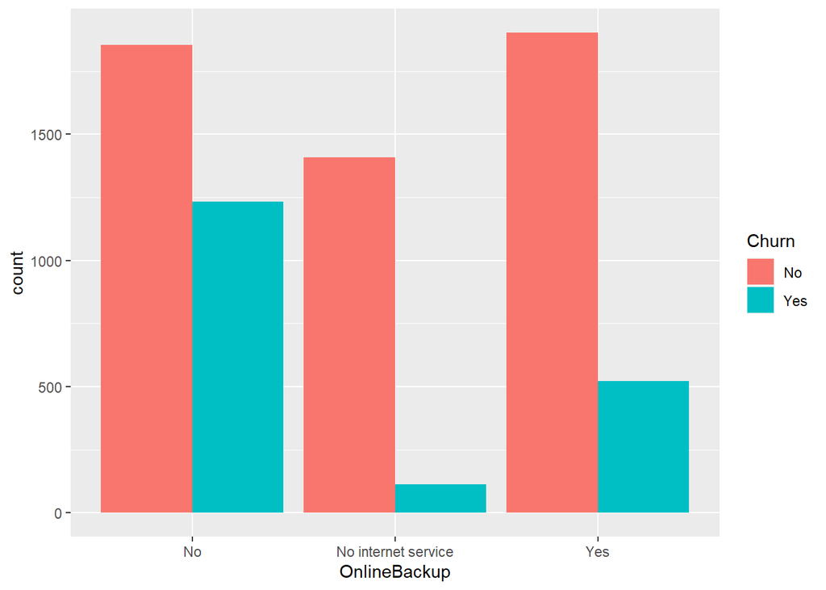

```r
ggplot(CR, aes(x = OnlineBackup, fill = Churn)) + geom_bar(position = "dodge")
```

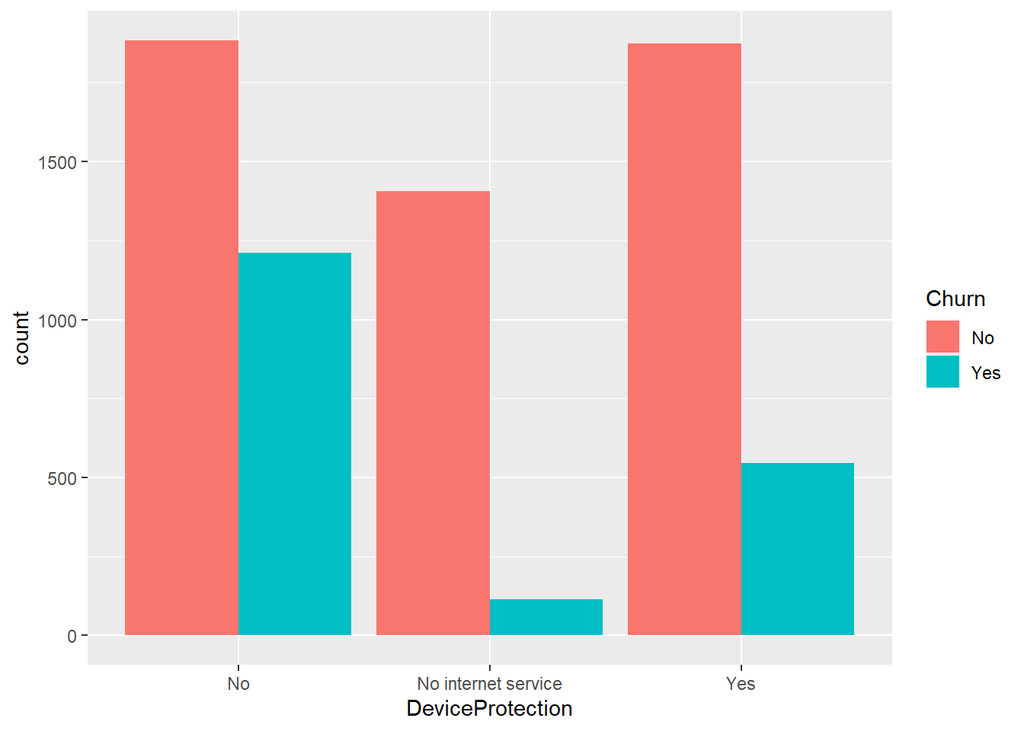

```r
ggplot(CR, aes(x = DeviceProtection, fill = Churn)) + geom_bar(position = "dodge")
```

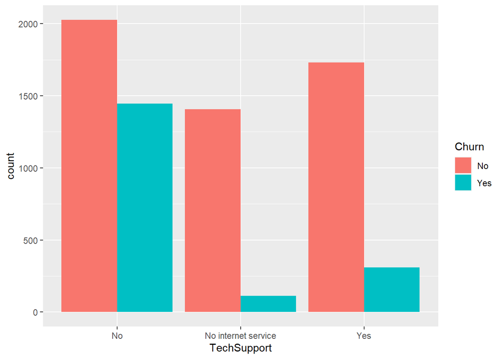

```r
ggplot(CR, aes(x = TechSupport, fill = Churn)) + geom_bar(position = "dodge")
```

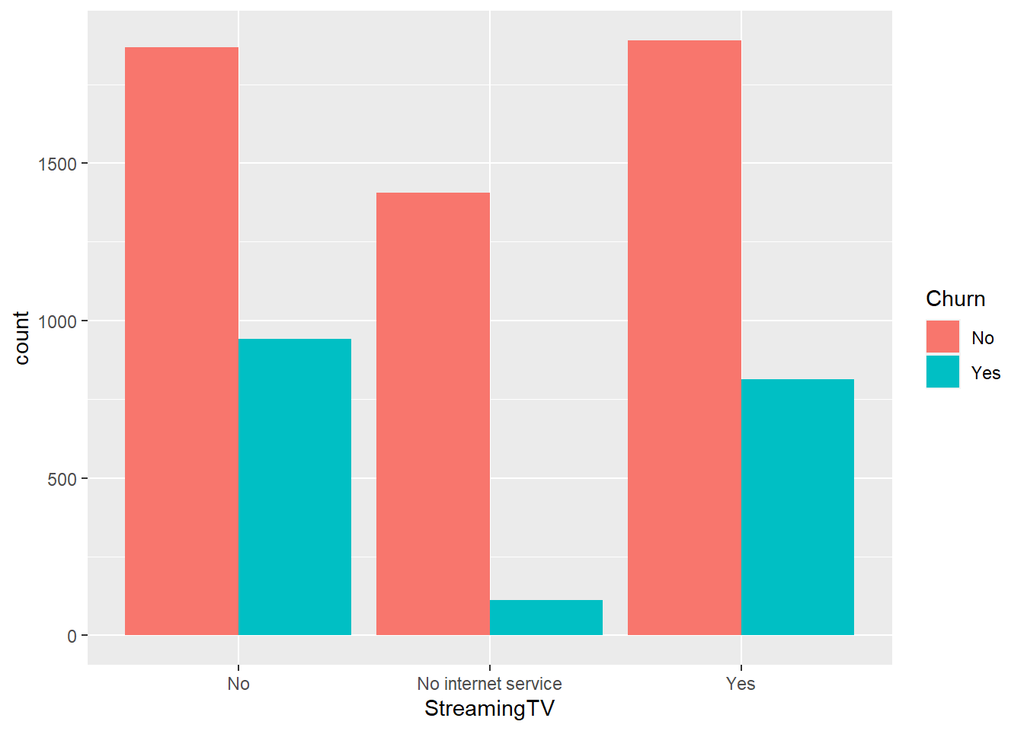

```r
ggplot(CR, aes(x = StreamingTV, fill = Churn)) + geom_bar(position = "dodge")
```

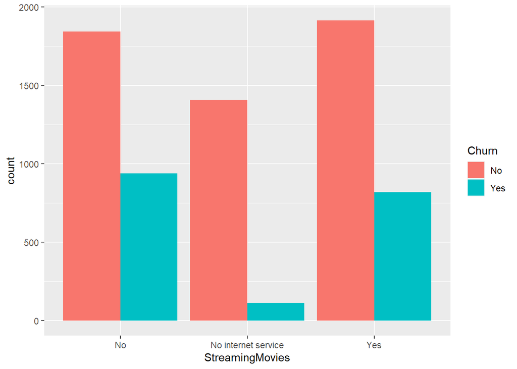

```r
ggplot(CR, aes(x = StreamingMovies, fill = Churn)) + geom_bar(position = "dodge")
```

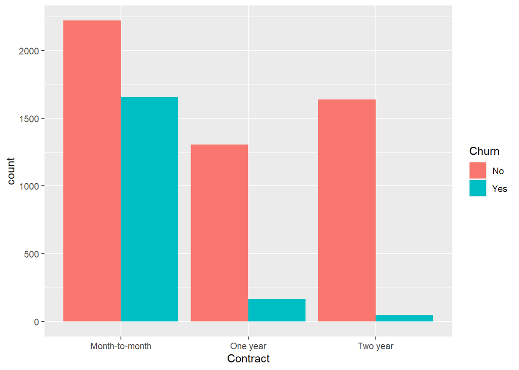

```r
ggplot(CR, aes(x = Contract, fill = Churn)) + geom_bar(position = "dodge")
```

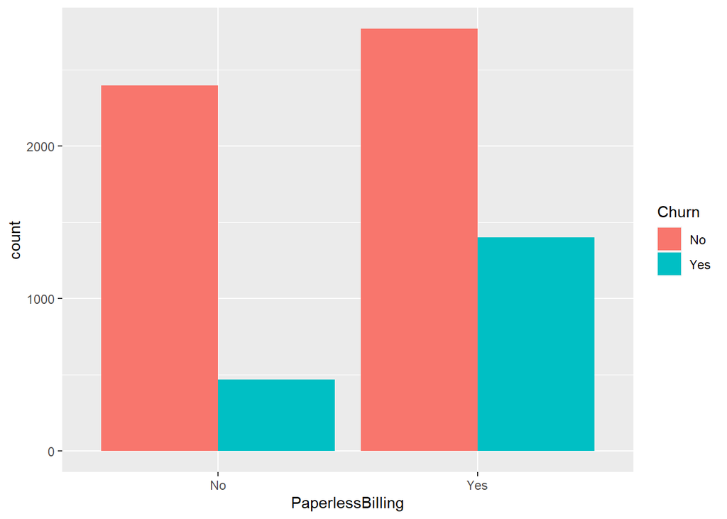

```r
ggplot(CR, aes(x = PaperlessBilling, fill = Churn)) + geom_bar(position = "dodge")
```

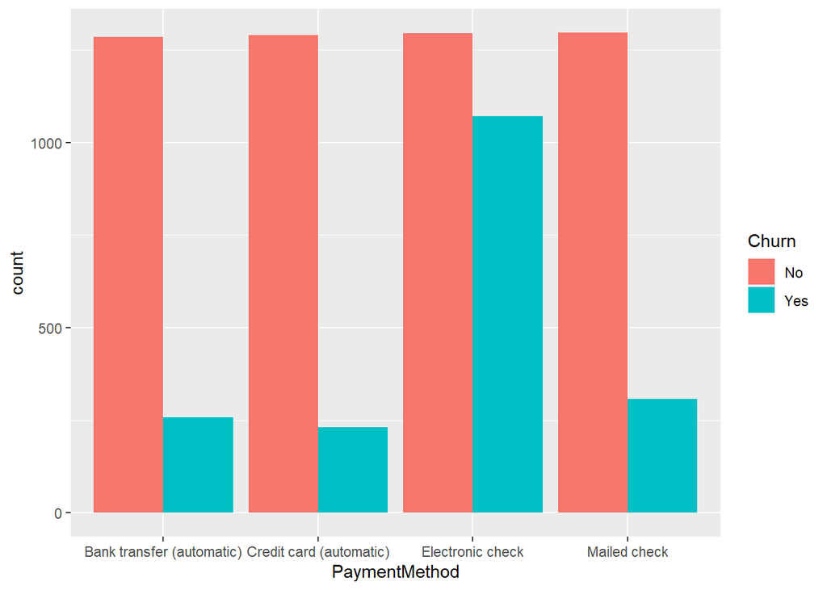

```r
ggplot(CR, aes(x = PaymentMethod, fill = Churn)) + geom_bar(position = "dodge")
```

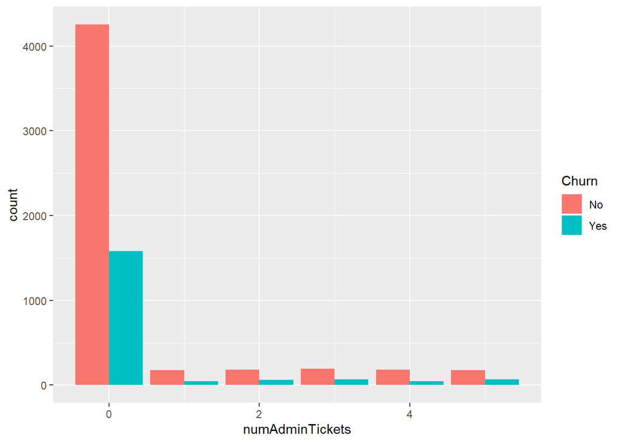

```r
ggplot(CR, aes(x = numAdminTickets, fill = Churn)) + geom_bar(position = "dodge")
```

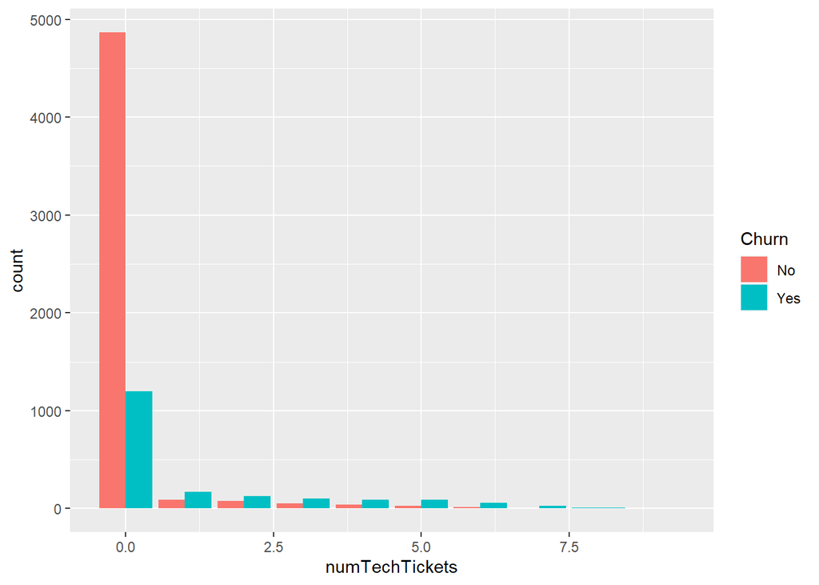

```r
ggplot(CR, aes(x = numTechTickets, fill = Churn)) + geom_bar(position = "dodge")
```

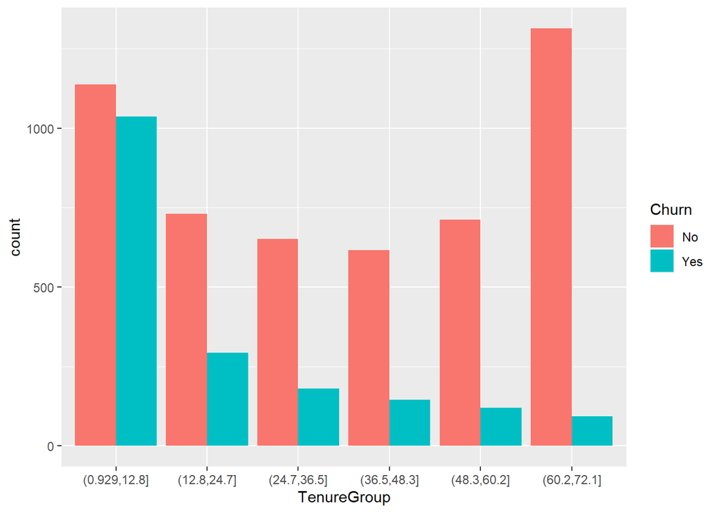

```r
ggplot(CR, aes(x = TenureGroup, fill = Churn)) + geom_bar(position = "dodge")
```

**2. Lets convert the target variable ‘Churn’ in a binary numeric variable i.e. Yes=1 ; No = 0**

```r
#CR$Churn <- as.factor(mapvalues(CR$SeniorCitizen, from = c("0", "1"), to = c("No", "Yes")))
CR$Churn <- ifelse(CR$Churn == "Yes",1,0)
```

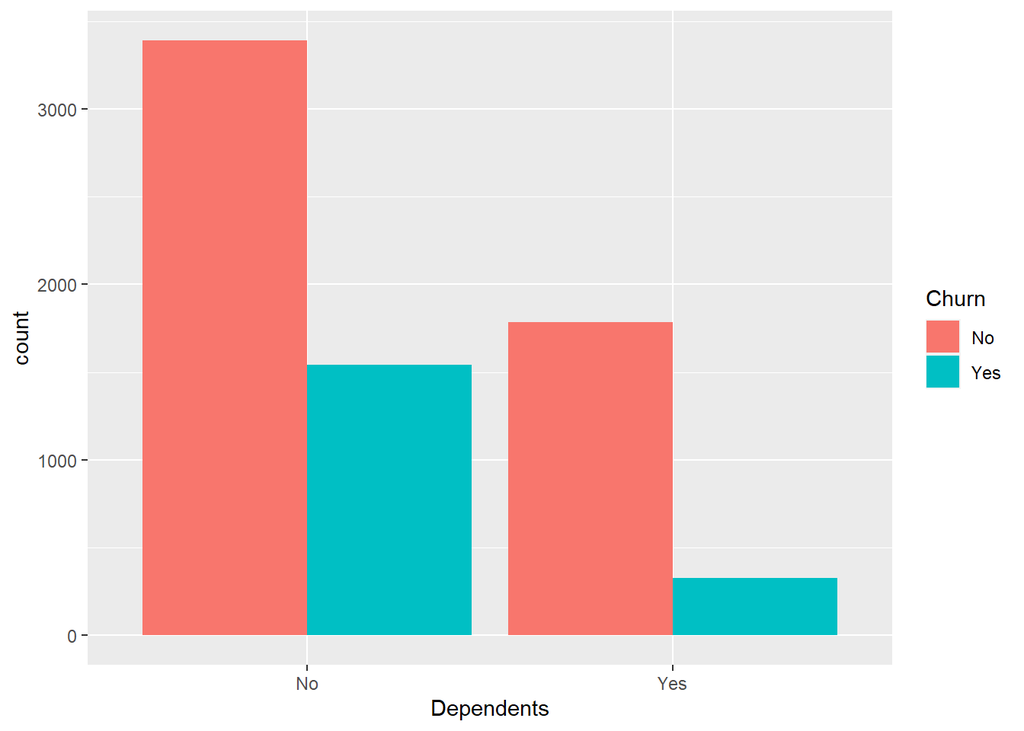

```r
ggplot(ChurnData, aes(x = Dependents, fill = Churn)) + geom_bar(position = "dodge")
```

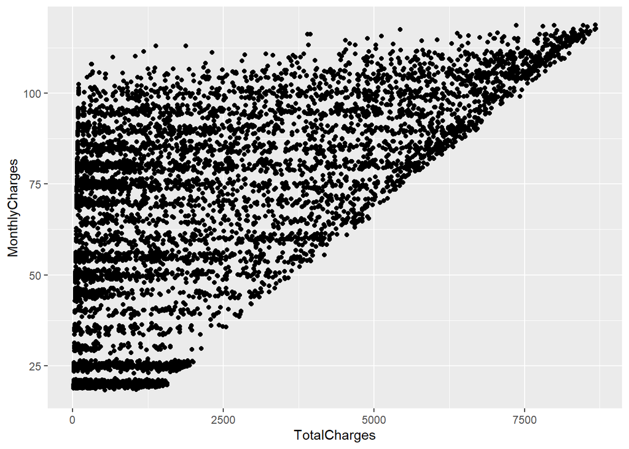

```r
ggplot(CR, aes(x = TotalCharges, y = MonthlyCharges)) + geom_point()
```

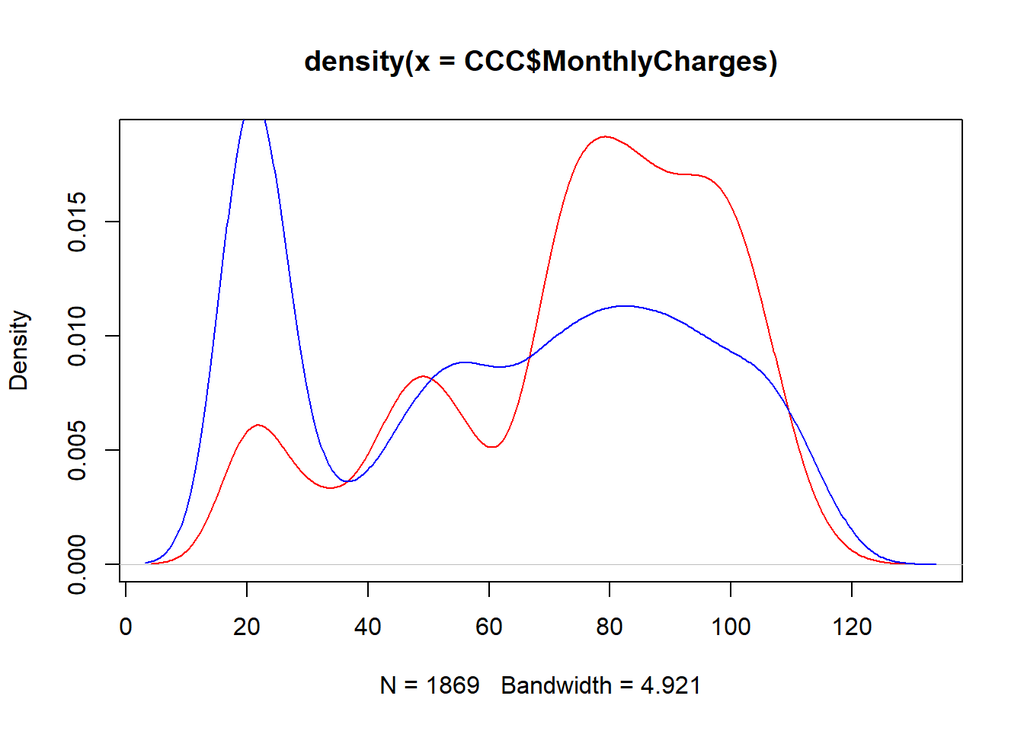

```r
CCC <- CR |> filter(Churn == 1)
plot(density(x = CCC$MonthlyCharges), col = 'red')
CCC2 <- CR |> filter(Churn == 0)
lines(density(x = CCC2$MonthlyCharges), col = 'blue')
```

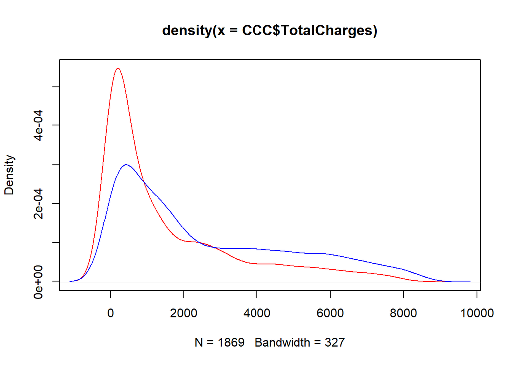

```r
plot(density(x = CCC$TotalCharges), col = 'red')
lines(density(x = CCC2$TotalCharges), col = 'blue')
```

**Surprising insight as higher Churn at lower Total Charges**

However if we combine the insights of 3 parameters i.e. Tenure, Monthly Charges & Total Charges then the picture is bit clear :- Higher Monthly Charge at lower tenure results into lower Total Charge. Hence, all these 3 factors viz **Higher Monthly Charge**, **Lower tenure** and **Lower Total Charge** are linked to **High Churn**. >Mth = sns.kdeplot(CRA_Dummies.TotalCharges[(CRA_Dummies[“Churn”] == 0) ], color=“Red”, fill = True) Mth = sns.kdeplot(CRA_Dummies.TotalCharges[(CRA_Dummies[“Churn”] == 1) ], ax =Mth, color=“Blue”, fill= True) Mth.legend([“No Churn”,“Churn”],loc=‘upper right’) Mth.set_ylabel(‘Density’) Mth.set_xlabel(‘Total Charges’) Mth.set_title(‘Total charges by churn’)

**Thats the python code for the kde plot above** **6. Build a corelation of all predictors with ‘Churn’**

```r
library(correlationfunnel)
CR_tbl <- CR |> binarize(n_bins = 5,thresh_infreq = 0.01,name_infreq = "OTHER",one_hot = TRUE)
```

```r
CR_tbl
```

```
## # A tibble: 7,032 × 75
##    gender__Female gender__Male SeniorCitizen__0 SeniorCitizen__1 Partner__No
##             <dbl>        <dbl>            <dbl>            <dbl>       <dbl>
##  1              1            0                1                0           0
##  2              0            1                1                0           1
##  3              0            1                1                0           1
##  4              0            1                1                0           1
##  5              1            0                1                0           1
##  6              1            0                1                0           1
##  7              0            1                1                0           1
##  8              1            0                1                0           1
##  9              1            0                1                0           0
## 10              0            1                1                0           1
## # ℹ 7,022 more rows
## # ℹ 70 more variables: Partner__Yes <dbl>, Dependents__No <dbl>,
## #   Dependents__Yes <dbl>, PhoneService__No <dbl>, PhoneService__Yes <dbl>,
## #   MultipleLines__No <dbl>, MultipleLines__No_phone_service <dbl>,
## #   MultipleLines__Yes <dbl>, InternetService__DSL <dbl>,
## #   InternetService__Fiber_optic <dbl>, InternetService__No <dbl>,
## #   OnlineSecurity__No <dbl>, OnlineSecurity__No_internet_service <dbl>, …
```

```r
CR_cor <- CR_tbl |> correlate(Churn__1)
```

```r
CR_cor
```

```
## # A tibble: 75 × 3
##    feature         bin              correlation
##    <fct>           <chr>                  <dbl>
##  1 Churn           0                     -1
##  2 Churn           1                      1
##  3 Contract        Month-to-month         0.405
##  4 numTechTickets  0                     -0.388
##  5 OnlineSecurity  No                     0.342
##  6 TechSupport     No                     0.337
##  7 TenureGroup     (0.929,12.8]           0.320
##  8 InternetService Fiber_optic            0.307
##  9 Contract        Two_year              -0.302
## 10 PaymentMethod   Electronic_check       0.301
## # ℹ 65 more rows
```

Visualization

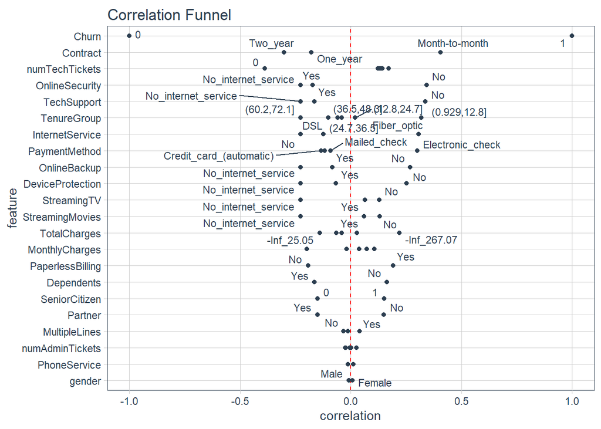

```r
plot_correlation_funnel(CR_cor)
```

#### Bivariate Analysis

We are going to seperate the target variable into different dataframes to get the analysis of Churned customers and thse who didnt Churn.

```r
CR_0 <- CR |> filter(Churn == 0)
CR_1 <- CR |> filter(Churn == 1)
```

Partner by Gender

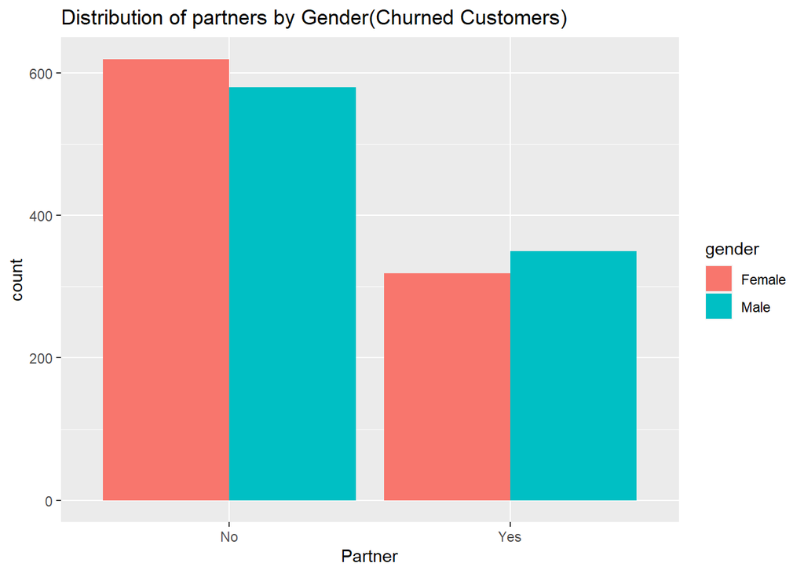

```r
ggplot(CR_1, aes(x = Partner, fill = gender)) + geom_bar(position = "dodge") + labs(title = "Distribution of partners by Gender(Churned Customers)")
```

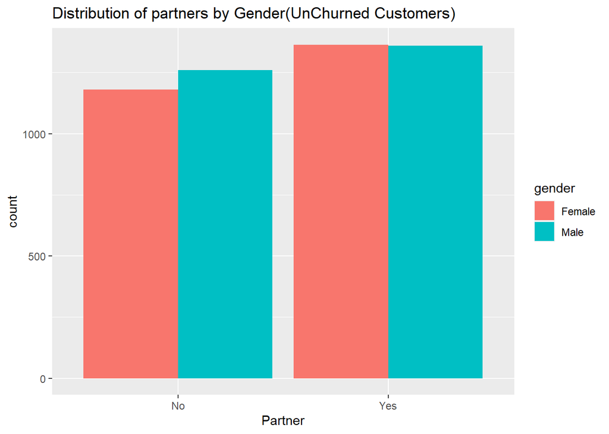

```r
ggplot(CR_0, aes(x = Partner, fill = gender)) + geom_bar(position = "dodge") + labs(title = "Distribution of partners by Gender(UnChurned Customers)")
```

**From the above analysis we can see that more people tends to quit services when theyre not a partner compare to when they are, and more likely those without Partnership in the Unchurned group of Customers will more likely quit faster in the future.**

#### Lets take other variables into case study in the Churned Customers Dataset

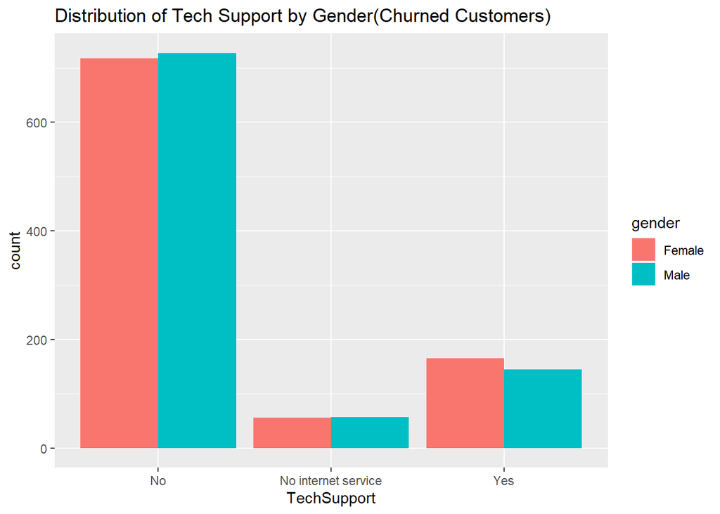

```r
ggplot(CR_1, aes(x = TechSupport, fill = gender)) + geom_bar(position = "dodge") + labs(title = "Distribution of Tech Support by Gender(Churned Customers)")
```

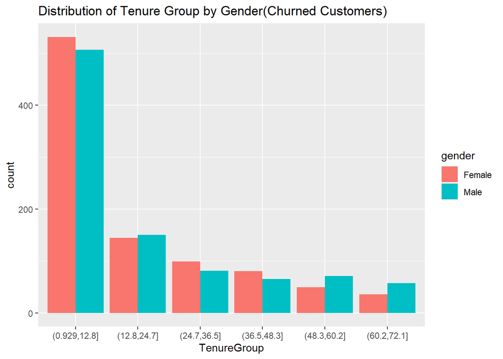

```r
ggplot(CR_1, aes(x = TenureGroup, fill = gender)) + geom_bar(position = "dodge") + labs(title = "Distribution of Tenure Group by Gender(Churned Customers)")
```

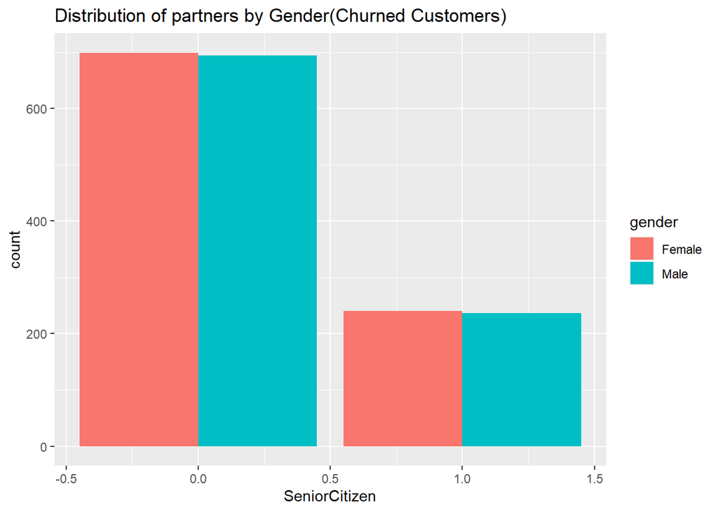

```r
ggplot(CR_1, aes(x = SeniorCitizen, fill = gender)) + geom_bar(position = "dodge") + labs(title = "Distribution of partners by Gender(Churned Customers)")
```

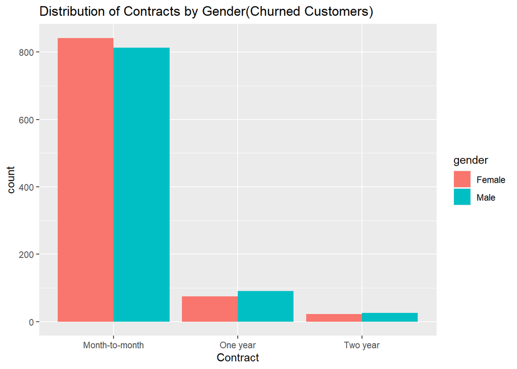

```r
ggplot(CR_1, aes(x = Contract, fill = gender)) + geom_bar(position = "dodge") + labs(title = "Distribution of Contracts by Gender(Churned Customers)")
```

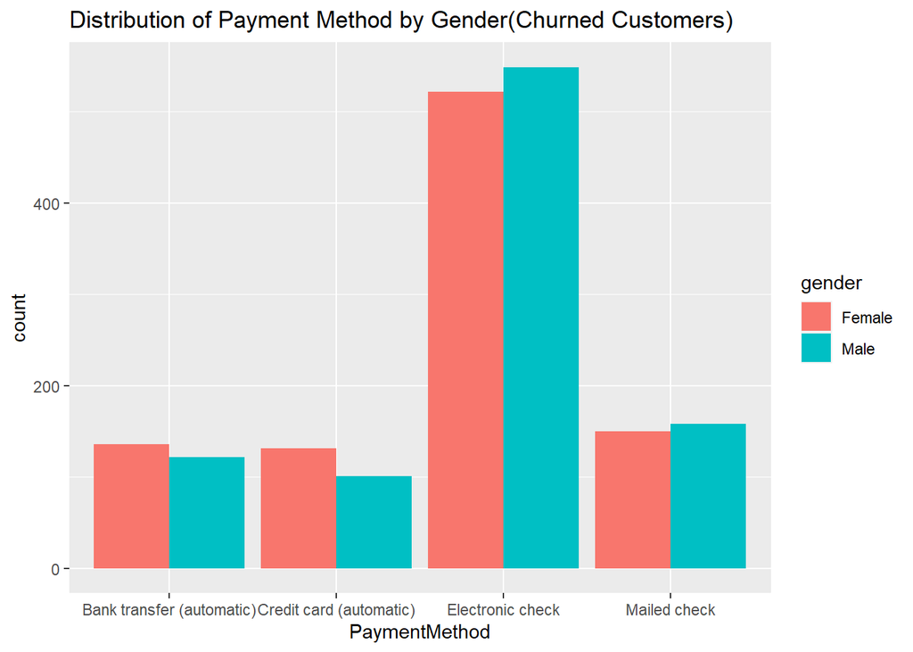

```r
ggplot(CR_1, aes(x = PaymentMethod, fill = gender)) + geom_bar(position = "dodge") + labs(title = "Distribution of Payment Method by Gender(Churned Customers)")
```

### CONCLUSION

Note: There could be many more such insights, so take this as an assignment and try to get more insights :)